# A frequentist test of proportional colocalization after selecting relevant genetic variants

Ashish Patel, John C. Whittaker, & Stephen Burgess

February 2024

$$\\$$

#### Genetic variant associations with *GLP1R* expression in different tissues

We consider a colocalization analysis of gene expression in different tissues in the *GLP1R* gene region. Such analyses are of potentially of interest when investigating causal mechanisms by which GLP1R agonists affect disease risk.

We start by loading the relevant genetic association data. Estimated genetic variant associations with gene expression based on n=838 participants of mostly European ancestry were taken from the Genotype-Tissue Expression (GTEx) project version 8. Estimated genetic variant correlations based on 367,703 unrelated participants were taken from the UK Biobank. We considered the genetic region ±100kbp of the GLP1R gene (chr6:39,016,557-39,059,079 in GRCh37/hg19) for which 851 variant associations with GLP1R expression were available.

The relevant data is stored in the “prop.coloc” R package. Lets load the package and see what the data looks like – for example, genetic associations with *GLP1R* expression at the brain (caudate) tissue:

```r
library("prop.coloc")
head(GLP1R$caudate)
```

|  | SNP | chr | chrpos | effect | other | maf | beta | se | pval |
| --- | --- | --- | --- | --- | --- | --- | --- | --- | --- |
| 1003 | rs10023 | 6 | chr6_39104258_A_G | G | A | 0.2242270 | -0.00131754 | 0.0870472 | 0.987941 |
| 776 | rs1004279 | 6 | chr6_39058009_G_A | A | G | 0.2757730 | -0.05245650 | 0.0836818 | 0.531552 |
| 778 | rs1004280 | 6 | chr6_39058106_A_G | G | A | 0.2757730 | -0.05245650 | 0.0836818 | 0.531552 |
| 1242 | rs1019772 | 6 | chr6_39152949_A_G | G | A | 0.1082470 | -0.12492200 | 0.1213340 | 0.304598 |
| 728 | rs10305414 | 6 | chr6_39047636_T_G | G | T | 0.0644330 | -0.05530840 | 0.1498980 | 0.712583 |
| 729 | rs10305415 | 6 | chr6_39047653_T_C | C | T | 0.0335052 | 0.06247040 | 0.2105540 | 0.767043 |

We now set up our inputs for proportional colocalization analyses. We select *GLP1R* expression in the two heart tissues as traits.

```r
traits <- c("heart (atrial appen.)","heart (left ventricle)")

# variant positions are required for the coloc methods
pos.split <- strsplit(GLP1R$atrial_appendage$chrpos,"_")
pos.split.fun <- function(s){as.numeric(pos.split[[s]][2])}; pos.split.fun <- sapply(1:851,pos.split.fun)
GLP1R$atrial_appendage$chrpos <- pos.split.fun

# collect the relevant beta-coefficients and standard errors
b1 <- GLP1R$atrial_appendage$beta; b2 <- GLP1R$left_ventricle$beta
se1 <- GLP1R$atrial_appendage$se; se2 <- GLP1R$left_ventricle$se
p1 <- GLP1R$atrial_appendage$pval; p2 <- GLP1R$left_ventricle$pval
mafs1 <- GLP1R$atrial_appendage$maf; mafs2 <- GLP1R$left_ventricle$maf
pos <- GLP1R$atrial_appendage$chrpos; ld <- GLP1R$ld
n <- 838
```

$$\\$$

#### Bayesian colocalization analysis

We now set up the inputs for Bayesian coloc analyses:

```r
library(coloc)
# prepare datasets for coloc analysis
dat1 <- list()
dat1$beta <- b1; names(dat1$beta) <- as.character(1:length(b1))
dat1$varbeta <- se1^2; names(dat1$varbeta) <- as.character(1:length(b1))
dat1$N <- n; dat1$type <- "quant"
dat1$MAF <- mafs1; names(dat1$MAF) <- as.character(1:length(b1))
colnames(ld) <- as.character(1:length(b1)); rownames(ld) <- as.character(1:length(b1))
dat1$LD <- ld; dat1$snp <- as.character(1:length(b1))
dat1$position <- pos

dat2 <- list()
dat2$beta <- b2; names(dat2$beta) <- as.character(1:length(b2))
dat2$varbeta <- se2^2; names(dat2$varbeta) <- as.character(1:length(b2))
dat2$N <- n; dat2$type <- "quant"
dat2$MAF <- mafs2; names(dat2$MAF) <- as.character(1:length(b2))
colnames(ld) <- as.character(1:length(b2)); rownames(ld) <- as.character(1:length(b2))
dat2$LD <- ld; dat2$snp <- as.character(1:length(b2))
dat2$position <- pos
```

Lets plot the manhattan plots for the two traits using the plot_dataset function in coloc. The causal variants selected by coloc-SuSiE are highlighted.

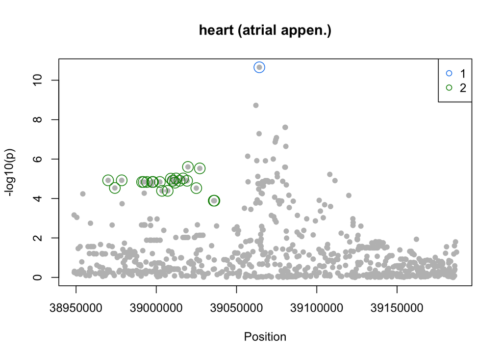

```r
suppressMessages(plot_dataset(dat1,runsusie(dat1), main=traits[1]))
```

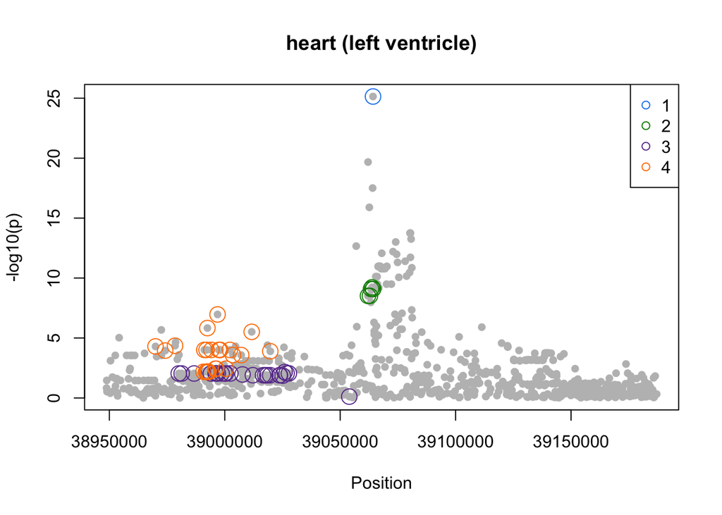

```r
suppressMessages(plot_dataset(dat2,runsusie(dat2), main=traits[2]))
```

Now we perform a coloc analysis using its default priors.

```r
suppressMessages(coloc.res <- coloc.abf(dataset1=dat1,dataset2=dat2))
```

```
## PP.H0.abf PP.H1.abf PP.H2.abf PP.H3.abf PP.H4.abf
##  2.24e-25  4.27e-21  5.41e-08  2.89e-05  1.00e+00
## [1] "PP abf for shared variant: 100%"
```

Coloc, which uses an assumption that there is at most a single causal variant for each trait, suggests that the two heart tissues colocalise.

We now perform a coloc-SuSiE analysis using its default priors.

```r
suppressMessages(susie.res <- coloc.susie(dat1,dat2))
susie.res$summary[,1:8]
```

| nsnps | hit1 | hit2 | PP.H0.abf | PP.H1.abf | PP.H2.abf | PP.H3.abf | PP.H4.abf |
| --- | --- | --- | --- | --- | --- | --- | --- |
| 851 | 310 | 310 | 3.870517e-29 | 9.768986e-22 | 7.957283e-11 | 8.394223e-06 | 0.999991606 |
| 851 | 186 | 310 | 9.427375e-20 | 3.910429e-19 | 1.938147e-01 | 8.039292e-01 | 0.002256133 |
| 851 | 310 | 715 | 1.713191e-08 | 4.324006e-01 | 2.222011e-08 | 5.608107e-01 | 0.006788701 |
| 851 | 186 | 715 | 8.117183e-02 | 3.366968e-01 | 1.052800e-01 | 4.366157e-01 | 0.040235697 |
| 851 | 310 | 425 | 1.102504e-08 | 2.782663e-01 | 2.839354e-08 | 7.166281e-01 | 0.005105578 |
| 851 | 186 | 425 | 5.371789e-02 | 2.228192e-01 | 1.383434e-01 | 5.738189e-01 | 0.011300727 |
| 851 | 310 | 282 | 7.478255e-09 | 1.887473e-01 | 3.205954e-08 | 8.091621e-01 | 0.002090532 |
| 851 | 186 | 282 | 7.257955e-03 | 3.010564e-02 | 3.111510e-02 | 1.274558e-01 | 0.804065521 |

Coloc-SuSiE suggests that two causal variants are shared by the two traits (with posterior probability of H4 > 0.999 at one variant, and posterior probability of H4 > 0.804 at another).

$$\\$$

#### Proportional colocalization analysis

Now we perform a proportional colocalization analysis. First, “prop-coloc-full” is based on all variants used to fit the linear variant-trait model. In contrast, “prop-coloc-cond” is a conditional proportional colocalization test based on only the lead variants.

Since the proportional colocalization test statistic is a function of the inverse of the variance-covariance matrix of genetic variants, we require some pruning (filtering out highly correlated variants) to ensure numerically stable results. The default choice in the prop.coloc function is an $R^2$ threshold of 0.6, so that moderately correlated variants are permitted. This threshold can be changed using the “prune” input.

The proportional colocalization method fits a multivariable variant-trait linear model involving the J=10 most relevant variants for each trait as a default. Again, this choice for the number of variants considered can be changed using the “J” input.

Other inputs required are the sample size (n) and the unconditional correlation between the two traits. Here, we select the correlation between *GLP1R* gene expression in the two heart tissues to be 0.5. This choice can be changed using the “tau” input (taken to be 0 as a default), and in practice exploring the sensitivity to the choice of tau is recommended.

With the proportional colocalization test, we are assessing the proportionality of estimated variant coefficients from a multivariable linear regression of each trait on multiple genetic variants. In this example, the methods fit a linear model involving 13 genetic variants that are among the J=10 most strongly associated variants with each of the two traits. To distinguish between these multivariable coefficients from the usual univariable (single variant) $\beta$-coefficients that are typically reported in GWAS summary data, we denote the multivariable coefficients $\gamma$.

We can now run the proportional colocalization test function.

```r
res <- prop.coloc(b1=b1, se1=se1, b2=b2, se2=se2, n=838, ld=ld, tau=0.5, figs=TRUE, traits=traits)
```

```
##
## Proportional colocalization test
##
## -----------------------------------
##           Method  eta p_LM p_coloc
##  prop-coloc-cond 0.78 0.00    0.46
##  prop-coloc-full 0.85 0.00    0.14
## -----------------------------------
##
## p_coloc assesses proportional colocalization hypothesis (rejection indicates failure to colocalize).
## p_LM assesses magnitude of the proportionality constant (rejection indicates proportionality constant is non-zero).
## Proportional colocalization is suggested when the colocalization hypothesis is not rejected and the proportionality constant is non-zero.
```

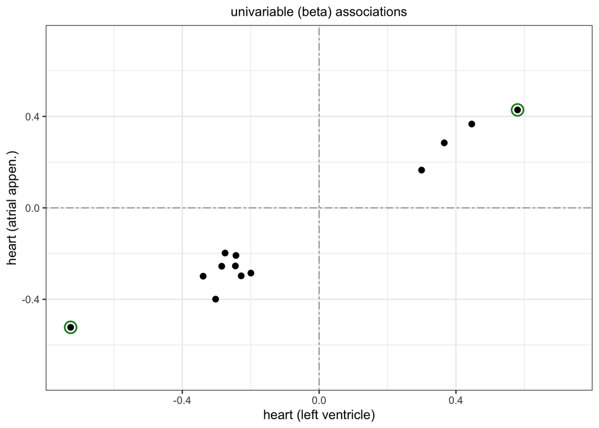

```r
res$fig_uni
```

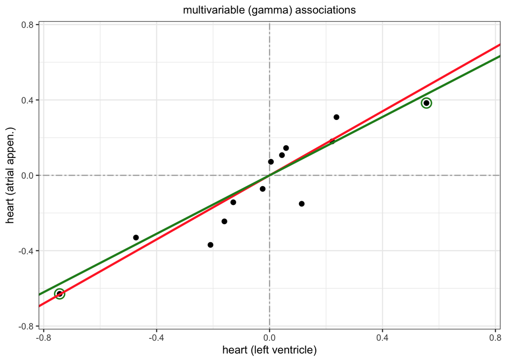

```r
res$fig_multi
```

By setting the input “figs” to TRUE, the function produces plots of the genetic associations with the two traits (*GLP1R* gene expression in heart-atrial appendage and heart-left ventricle) based on univariable (trait on individual genetic variant) and multivariable (trait on multiple genetic variants) linear regressions.

In the above plots, the two lead variants selected by the prop-coloc-cond method are circled in green. The slopes indicate the estimated proportionality constant from the prop-coloc-full (red) and prop-coloc-cond (green) methods. The proportionality constant estimates, and corresponding p-values of LM tests from the prop-coloc-full and prop-coloc-cond methods are:

```r
# proportionality constant using the 10 most relevant variants for each trait
round(res$eta_full,2)
```

```
## [1] 0.85
```

```r
# LM test p-value using the 10 most relevant variants for each trait
round(res$LM_full,2)
```

```
## [1] 0
```

```r
# proportionality constant based on the lead variants
round(res$eta_cond,2)
```

```
## [1] 0.78
```

```r
# LM test p-value based on the lead variants
round(res$LM_cond,2)
```

```
## [1] 0
```

Therefore, the LM test suggests evidence of a non-zero proportionality constant. We now consider the p-values when testing the proportional colocalization hypothesis using the prop-coloc-full method, and the prop-coloc-cond method:

```r
# prop-coloc-full p-value (using the 10 most relevant variants for each trait)
round(res$p_full,2)
```

```
## [1] 0.14
```

```r
# prop-coloc-cond p-value (based on the lead variants only)
res$p_cond
```

```
## [1] 0.46
```

Thus, for a 5% level test, we cannot reject the null hypothesis of proportional colocalization.

$$\\$$

#### Summary

In conclusion, all the colocalization methods we considered suggest evidence for colocalization of *GLP1R* gene expression in the heart-atrial appendage and heart-left ventricle tissues.